# Cats and Dogs

### Objective

Try to predict if a give image belongs to a cat or a dog.

```python
import tensorflow as tf
import numpy as np
import matplotlib.pyplot as plt
from tqdm import tqdm
from IPython.display import display, Image, HTML
import os
import cv2

TRAIN_DIR = '/input/train'
TEST_DIR = '/input/test'
IMG_SIZE = 64
```

### Input Data

Resize the image to `IMG_SIZE * IMG_SIZE`, then normailze each pixel and return the image

```python
def create_input_data(im):
#     img = cv2.imread(im, cv2.IMREAD_COLOR)
#     if (img.shape[0] >= img.shape[1]): # height is greater than width
#        resizeto = (IMG_SIZE, int (round (IMG_SIZE * (float (img.shape[1])  / img.shape[0]))));
#     else:
#        resizeto = (int (round (IMG_SIZE * (float (img.shape[0])  / img.shape[1]))), IMG_SIZE);

#     img2 = cv2.resize(img, (resizeto[1], resizeto[0]), interpolation=cv2.INTER_CUBIC)
#     img3 = cv2.copyMakeBorder(img2, 0, IMG_SIZE - img2.shape[0], 0, IMG_SIZE - img2.shape[1], cv2.BORDER_CONSTANT, 0)

#     return img3[:,:,::-1]
    img = cv2.imread(im, cv2.IMREAD_COLOR)
    img = cv2.resize(img, (IMG_SIZE, IMG_SIZE))
    return np.array(img / 255)
```

### Output Labels

Create a method which will one-hot-encodes the target labels

```python
def one_hot_encode(img):
    if 'cat' in img:
        return np.array([0, 1])
    else:
        return np.array([1, 0])
```

### Now create the input and output data

```python
training_img = []
training_label = []

testing_img = []
testing_label = []

for img in tqdm(os.listdir(TRAIN_DIR)):
    training_path = os.path.join(TRAIN_DIR, img)

    train_img = create_input_data(training_path)
    training_img.append(np.array(train_img))

    train_label = one_hot_encode(img)
    training_label.append(np.array(train_label))

for img in tqdm(os.listdir(TEST_DIR)):
    testing_path = os.path.join(TEST_DIR, img)

    test_img = create_input_data(testing_path)
    testing_img.append(np.array(test_img))

    test_label = one_hot_encode(img)
    testing_label.append(np.array(test_label))

training_img = np.array(training_img, dtype=np.float32)
training_label = np.array(training_label, dtype=np.float32)

testing_img = np.array(testing_img, dtype=np.float32)
testing_label = np.array(testing_label, dtype=np.float32)
```

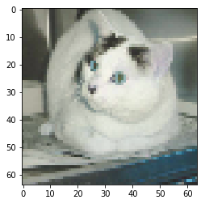

```
[ 0.  1.]
```

```python
index = 15000
plt.imshow(training_img[index])
plt.show()
print(training_label[index])
```

### Input

The neural network needs to read the image data, one-hot encoded labels, and dropout keep probability. Implement the following functions

- Implement neural_net_image_input
  - Return a TF Placeholder
  - Set the shape using image_shape with batch size set to None.
  - Name the TensorFlow placeholder "x" using the TensorFlow name parameter in the TF Placeholder.
- Implement neural_net_label_input
  - Return a TF Placeholder
  - Set the shape using n_classes with batch size set to None.
  - Name the TensorFlow placeholder "y" using the TensorFlow name parameter in the TF Placeholder.
- Implement neural_net_keep_prob_input
  - Return a TF Placeholder for dropout keep probability.
  - Name the TensorFlow placeholder "keep_prob" using the TensorFlow name parameter in the TF Placeholder.
  - These names will be used at the end of the project to load your saved model.

Note: *None* for shapes in TensorFlow allow for a dynamic size.

```python
def neural_net_image_input(image_size):
    return tf.placeholder(tf.float32, [None] + list(image_size), 'x')

def neural_net_label_input():
    return tf.placeholder(tf.float32, [None, 2], 'y')

def neural_net_keep_prob():
    return tf.placeholder(tf.float32, None, 'keep_prob')
```

### Convolution and Max Pooling Layer

Convolution layers have a lot of success with images. For this code cell, you should implement the function conv2d_maxpool to apply convolution then max pooling:

- Create the weight and bias using `conv_ksize`, `conv_num_outputs` and the shape of `x_tensor`.
- Apply a convolution to `x_tensor` using weight and `conv_strides`.
  - We recommend you use same padding, but you're welcome to use any padding.
- Add bias
- Add a nonlinear activation to the convolution.
- Apply Max Pooling using `pool_ksize` and `pool_strides`.
  - We recommend you use same padding, but you're welcome to use any padding.

```python
def conv2d_maxpool(x_tensor, conv_num_outputs, conv_ksize=(2,2), conv_strides=[1,1,1,1], pool_ksize=[1,2,2,1], pool_strides=[1,2,2,1]):
    dimension = x_tensor.get_shape().as_list()
    shape = list(conv_ksize + (dimension[-1],) + (conv_num_outputs,))
    weight = tf.Variable(tf.truncated_normal(shape, 0, 0.1))
    bias = tf.Variable(tf.zeros(conv_num_outputs))

    conv_layer = tf.nn.conv2d(x_tensor, weight, strides=conv_strides, padding='SAME')
    conv_layer = tf.nn.bias_add(conv_layer, bias)
    conv_layer = tf.nn.relu(conv_layer)

    conv_layer = tf.nn.max_pool(conv_layer, ksize=pool_ksize, strides=pool_strides, padding='SAME')

    return conv_layer
```

### Flatten Layer

Implement the `flatten` function to change the dimension of `x_tensor` from a 4-D tensor to a 2-D tensor. The output should be the shape (Batch Size, Flattened Image Size).

```python
def flatten(x_tensor):
    dimension = x_tensor.get_shape().as_list()
    return tf.reshape(x_tensor, [-1, np.prod(dimension[1:])])
```

### Fully-Connected Layer

Implement the `fully_conn` function to apply a fully connected layer to `x_tensor` with the shape (Batch Size, num_outputs).

```python
def fully_conn(x_tensor, num_outputs):
    dimension = x_tensor.get_shape().as_list()
    shape = list((dimension[-1],) + (num_outputs,))
    weights = tf.Variable(tf.truncated_normal(shape, 0, 0.1))
    bias = tf.Variable(tf.zeros(num_outputs))

    fully_conn = tf.nn.relu(tf.add(tf.matmul(x_tensor, weights), bias))

    return fully_conn
```

### Output Layer

Implement the `output` function to apply a fully connected layer to `x_tensor` with the shape (Batch Size, num_outputs).

**Note:** Activation, softmax, or cross entropy should **not** be applied to this.

```python
def output(x_tensor, num_outputs):
    dimension = x_tensor.get_shape().as_list()
    shape = list((dimension[-1],) + (num_outputs,))
    weights = tf.Variable(tf.truncated_normal(shape, 0, 0.01))
    bias = tf.Variable(tf.zeros(num_outputs))

    output = tf.add(tf.matmul(x_tensor, weights), bias)

    return output
```

### Create Convolutional Model

- Implement the function conv_net to create a convolutional neural network model. The function takes in a batch of images, x, and outputs logits. Use the layers you created above to create this model:
- Apply 1, 2, or 3 Convolution and Max Pool layers
- Apply a Flatten Layer
- Apply 1, 2, or 3 Fully Connected Layers
- Apply an Output Layer
- Return the output
- Apply TensorFlow's Dropout to one or more layers in the model using keep_prob.

```python
def conv_net(x, keep_prob):

    model = conv2d_maxpool(x, conv_num_outputs=64)
    model = tf.nn.dropout(model, keep_prob)

#     model = conv2d_maxpool(x, conv_num_outputs=64)
#     model = tf.nn.dropout(model, keep_prob)

    model = conv2d_maxpool(x, conv_num_outputs=128)
    model = tf.nn.dropout(model, keep_prob)

#     model = conv2d_maxpool(x, conv_num_outputs=128)
#     model = tf.nn.dropout(model, keep_prob)

#     model = conv2d_maxpool(x, conv_num_outputs=256)
#     model = tf.nn.dropout(model, keep_prob)

#     model = conv2d_maxpool(x, conv_num_outputs=256)
#     model = tf.nn.dropout(model, keep_prob)

    model = flatten(model)
    model = tf.nn.dropout(model, keep_prob)

    model = fully_conn(model, 256)
#     model = fully_conn(model, 8)

    model = output(model, 2)

    return model

##############################
## Build the Neural Network ##
##############################

# Remove previous weights, bias, inputs, etc..
tf.reset_default_graph()

# Inputs
x = neural_net_image_input((IMG_SIZE, IMG_SIZE, 3))
y = neural_net_label_input()
keep_prob = neural_net_keep_prob()

# Model
logits = conv_net(x, keep_prob)

# Name logits Tensor, so that is can be loaded from disk after training
logits = tf.identity(logits, name='logits')

# Loss and Optimizer
cost = tf.reduce_mean(tf.nn.softmax_cross_entropy_with_logits(logits=logits, labels=y))
optimizer = tf.train.AdamOptimizer(1e-3).minimize(cost)

# Accuracy
correct_pred = tf.equal(tf.argmax(logits, 1), tf.argmax(y, 1))
accuracy = tf.reduce_mean(tf.cast(correct_pred, tf.float32), name='accuracy')
```

### Train the Neural Network

#### Single Optimization

Implement the function `train_neural_network` to do a single optimization. The optimization should use optimizer to optimize in session with a `feed_dict` of the following:

- x for image input
- y for labels
- keep_prob for keep probability for dropout This function will be called for each batch, so `tf.global_variables_initializer()` has already been called.

Note: Nothing needs to be returned. This function is only optimizing the neural network.

```python
def train_neural_network(session, optimizer, keep_probability, feature_batch, label_batch):
    session.run(optimizer, feed_dict={x:feature_batch, y:label_batch, keep_prob:keep_probability})
```

### Show Stats

```python
def print_stats(session, feature_batch, label_batch, cost, accuracy):
    loss = session.run(cost, feed_dict={x:feature_batch, y:label_batch, keep_prob:0.7})
    valid_acc = sess.run(accuracy, feed_dict={
                x: training_img[:batch_size],
                y: training_label[:batch_size],
                keep_prob: 0.7})
    print('Loss: {:>10.4f} Validation Accuracy: {:.6f}'.format(loss, valid_acc))
```

### Hyperparameters

Tune the following parameters:

- Set epochs to the number of iterations until the network stops learning or start overfitting
- Set batch_size to the highest number that your machine has memory for. Most people set them to common sizes of memory:
  - 64
  - 128
  - 256
  - ...
- Set `keep_probability` to the probability of keeping a node using dropout

```python
# TODO: Tune Parameters
epochs = 15
batch_size = 64
keep_probability = 0.7
```

### Train on a Single Batch

Instead of training the neural network on all the batches of data, let's use a single batch. This should save time while you iterate on the model to get a better accuracy.

```python
print('Checking the Training on a Single Batch...')
with tf.Session() as sess:
    # Initializing the variables
    sess.run(tf.global_variables_initializer())

    # Training cycle
    for epoch in range(epochs):
        batch_i = 1
        batch_features = training_img[:batch_size]
        batch_labels = training_label[:batch_size]

        train_neural_network(sess, optimizer, keep_probability, batch_features, batch_labels)

        print('Epoch {:>2}, Batch {}:  '.format(epoch + 1, batch_i), end='')
        print_stats(sess, batch_features, batch_labels, cost, accuracy)
```

[output not shown]

### Fully Train the Model

```python
save_model_path = './image_classification'
print('Training...')
with tf.Session() as sess:
    # Initializing the variables
    sess.run(tf.global_variables_initializer())

    # Training cycle
    for epoch in range(epochs):
        # Loop over all batches
        n_batches = 5
        for batch_i in range(1, n_batches + 1):
            batch_features = training_img[batch_i:batch_size]
            batch_labels = training_label[batch_i:batch_size]

            train_neural_network(sess, optimizer, keep_probability, batch_features, batch_labels)

            print('Epoch {:>2}, Batch {}:  '.format(epoch + 1, batch_i), end='')
            print_stats(sess, batch_features, batch_labels, cost, accuracy)

    # Save Model
    saver = tf.train.Saver()
    save_path = saver.save(sess, save_model_path)
```

```
Training...
Epoch  1, Batch 1:  Loss:     1.3963 Validation Accuracy: 0.515625
Epoch  1, Batch 2:  Loss:     2.3100 Validation Accuracy: 0.484375
Epoch  1, Batch 3:  Loss:     1.5144 Validation Accuracy: 0.484375
Epoch  1, Batch 4:  Loss:     0.6316 Validation Accuracy: 0.531250
Epoch  1, Batch 5:  Loss:     0.7943 Validation Accuracy: 0.546875
Epoch  2, Batch 1:  Loss:     0.8501 Validation Accuracy: 0.515625
Epoch  2, Batch 2:  Loss:     0.7998 Validation Accuracy: 0.515625
Epoch  2, Batch 3:  Loss:     0.7251 Validation Accuracy: 0.515625
Epoch  2, Batch 4:  Loss:     0.6778 Validation Accuracy: 0.531250
Epoch  2, Batch 5:  Loss:     0.6495 Validation Accuracy: 0.640625
Epoch  3, Batch 1:  Loss:     0.6406 Validation Accuracy: 0.718750
Epoch  3, Batch 2:  Loss:     0.6574 Validation Accuracy: 0.703125
Epoch  3, Batch 3:  Loss:     0.6518 Validation Accuracy: 0.546875
Epoch  3, Batch 4:  Loss:     0.6422 Validation Accuracy: 0.531250
Epoch  3, Batch 5:  Loss:     0.6704 Validation Accuracy: 0.515625
Epoch  4, Batch 1:  Loss:     0.6612 Validation Accuracy: 0.531250
Epoch  4, Batch 2:  Loss:     0.6556 Validation Accuracy: 0.515625
Epoch  4, Batch 3:  Loss:     0.6471 Validation Accuracy: 0.515625
Epoch  4, Batch 4:  Loss:     0.6373 Validation Accuracy: 0.671875
Epoch  4, Batch 5:  Loss:     0.6311 Validation Accuracy: 0.781250
Epoch  5, Batch 1:  Loss:     0.6037 Validation Accuracy: 0.828125
Epoch  5, Batch 2:  Loss:     0.5935 Validation Accuracy: 0.781250
Epoch  5, Batch 3:  Loss:     0.5943 Validation Accuracy: 0.734375
Epoch  5, Batch 4:  Loss:     0.5542 Validation Accuracy: 0.734375
Epoch  5, Batch 5:  Loss:     0.5527 Validation Accuracy: 0.812500
Epoch  6, Batch 1:  Loss:     0.5169 Validation Accuracy: 0.828125
Epoch  6, Batch 2:  Loss:     0.4942 Validation Accuracy: 0.812500
Epoch  6, Batch 3:  Loss:     0.5000 Validation Accuracy: 0.843750
Epoch  6, Batch 4:  Loss:     0.4554 Validation Accuracy: 0.875000
Epoch  6, Batch 5:  Loss:     0.4541 Validation Accuracy: 0.921875
Epoch  7, Batch 1:  Loss:     0.3888 Validation Accuracy: 0.921875
Epoch  7, Batch 2:  Loss:     0.3841 Validation Accuracy: 0.875000
Epoch  7, Batch 3:  Loss:     0.3518 Validation Accuracy: 0.906250
Epoch  7, Batch 4:  Loss:     0.3403 Validation Accuracy: 0.953125
Epoch  7, Batch 5:  Loss:     0.3095 Validation Accuracy: 0.953125
Epoch  8, Batch 1:  Loss:     0.2786 Validation Accuracy: 0.937500
Epoch  8, Batch 2:  Loss:     0.2711 Validation Accuracy: 0.968750
Epoch  8, Batch 3:  Loss:     0.2193 Validation Accuracy: 0.968750
Epoch  8, Batch 4:  Loss:     0.2088 Validation Accuracy: 0.984375
```

[output cut: 21 more lines]

```
Epoch 13, Batch 1:  Loss:     0.0130 Validation Accuracy: 1.000000
Epoch 13, Batch 2:  Loss:     0.0087 Validation Accuracy: 1.000000
Epoch 13, Batch 3:  Loss:     0.0068 Validation Accuracy: 1.000000
Epoch 13, Batch 4:  Loss:     0.0101 Validation Accuracy: 1.000000
Epoch 13, Batch 5:  Loss:     0.0061 Validation Accuracy: 1.000000
Epoch 14, Batch 1:  Loss:     0.0071 Validation Accuracy: 1.000000
Epoch 14, Batch 2:  Loss:     0.0049 Validation Accuracy: 1.000000
Epoch 14, Batch 3:  Loss:     0.0045 Validation Accuracy: 1.000000
Epoch 14, Batch 4:  Loss:     0.0050 Validation Accuracy: 1.000000
Epoch 14, Batch 5:  Loss:     0.0060 Validation Accuracy: 1.000000
Epoch 15, Batch 1:  Loss:     0.0062 Validation Accuracy: 1.000000
Epoch 15, Batch 2:  Loss:     0.0031 Validation Accuracy: 1.000000
Epoch 15, Batch 3:  Loss:     0.0039 Validation Accuracy: 1.000000
Epoch 15, Batch 4:  Loss:     0.0042 Validation Accuracy: 1.000000
Epoch 15, Batch 5:  Loss:     0.0062 Validation Accuracy: 1.000000
```

### Test Model

Test your model against the test dataset. This will be your final accuracy. You should have an accuracy greater than 50%. If you don't, keep tweaking the model architecture and parameters.

```python
# Set batch size if not already set
try:
    if batch_size:
        pass
except NameError:
    batch_size = 64

save_model_path = './image_classification'
n_samples = 4
top_n_predictions = 3

def test_model():
    """
    Test the saved model against the test dataset
    """

#     test_features, test_labels = pickle.load(open('preprocess_training.p', mode='rb'))
    loaded_graph = tf.Graph()

    with tf.Session(graph=loaded_graph) as sess:
        # Load model
        loader = tf.train.import_meta_graph(save_model_path + '.meta')
        loader.restore(sess, save_model_path)

        # Get Tensors from loaded model
        loaded_x = loaded_graph.get_tensor_by_name('x:0')
        loaded_y = loaded_graph.get_tensor_by_name('y:0')
        loaded_keep_prob = loaded_graph.get_tensor_by_name('keep_prob:0')
        loaded_logits = loaded_graph.get_tensor_by_name('logits:0')
        loaded_acc = loaded_graph.get_tensor_by_name('accuracy:0')

        test_epoch = 25
        # Get accuracy in batches for memory limitations
        test_batch_acc_total = 0
        test_batch_count = 0

        n_batches = 500
        b_size = 0
        for i in range(25):
            test_batch_acc_total += sess.run(
                loaded_acc,
                feed_dict={loaded_x: testing_img[b_size:n_batches], loaded_y: testing_label[b_size:n_batches], loaded_keep_prob: 1.0})
            test_batch_count += 1

            print('Batch {:>2}:  Testing Accuracy: {}\n'.format(i + 1, test_batch_acc_total/test_batch_count), end='')

            b_size = n_batches + 1
            n_batches += 500


test_model()
```

```
Batch  1:  Testing Accuracy: 0.6159999966621399
Batch  2:  Testing Accuracy: 0.6166172921657562
Batch  3:  Testing Accuracy: 0.6074709892272949
Batch  4:  Testing Accuracy: 0.6134188771247864
Batch  5:  Testing Accuracy: 0.6137812018394471
Batch  6:  Testing Accuracy: 0.6163607537746429
Batch  7:  Testing Accuracy: 0.6170581408909389
Batch  8:  Testing Accuracy: 0.6110681518912315
Batch  9:  Testing Accuracy: 0.6135346359676785
Batch 10:  Testing Accuracy: 0.6117002189159393
Batch 11:  Testing Accuracy: 0.6094706004316156
Batch 12:  Testing Accuracy: 0.6107855886220932
Batch 13:  Testing Accuracy: 0.6114358122532184
Batch 14:  Testing Accuracy: 0.6139971528734479
Batch 15:  Testing Accuracy: 0.6142129739125569
Batch 16:  Testing Accuracy: 0.6137755662202835
Batch 17:  Testing Accuracy: 0.6136253826758441
Batch 18:  Testing Accuracy: 0.613380554649565
Batch 19:  Testing Accuracy: 0.6125286535212868
Batch 20:  Testing Accuracy: 0.6118621408939362
Batch 21:  Testing Accuracy: 0.6123088257653373
Batch 22:  Testing Accuracy: 0.6137169057672675
Batch 23:  Testing Accuracy: 0.6137827142425205
Batch 24:  Testing Accuracy: 0.6151790445049604
Batch 25:  Testing Accuracy: 0.6164636659622192
```